# STAT 240: Chapter 4: Introduction to Probability

# Overview

## Learning Outcome

These lecture notes will make you familiar with: - Basic statistical terms and their definitions - Probability concepts and using those to solve statistical questions - Distinguish between random processes, their outcomes, and the values of random variables

## Introduction

Every researcher starts with a question that needs to be answered. For instance, in medical research, a question can be asked about the effect of a drug that is to be administered; or an economist might be concerned about the prices of a select number of commodities over the time; or an agronomist may wish to study the effect that a fertilizer has on the yield of a crop.

The only way to elicit enough information to answer any such questions is to actually perform the experiments. Most experiments share the same characteristic, that is, if performed under the same conditions will more or less generate identical results. Roughly speaking, every research/study can be divided into three steps:

- Step 1: Identifying the research question, then designing an experiment, gathering sample, and collect some data.
- Step 2: Clean the raw data, explore it and figure out the best way to model it.
- Step 3: Enhancing the initial model to best fit the data and interpreting the results

Statistics is primarily the science of collecting, organizing, processing and analyzing data, in order to acquire useful information to answer most questions. In statistics, the group of interest is often vast and in most cases, it’s impractical to observe every member of such a vast group, but luckily, this is rarely necessary; a well-drawn subset is sufficient to answer most questions. Information collected from the subset, helps answer the questions about the large group.

It is often the case that we say anything is possible, yet if we want to know how possible an event is, then we employ *probability* which tells us the degree of the possibility. Probability and statistics are deeply connected because all statistical statements are, at bottom, statements about probability. Despite this, the two sometimes feel like very different subjects. Probability is logically self-contained; there are a few rules and all answers follow logically from the rules, though computations can be tricky. In statistics we apply probability to draw conclusions from data. This can be messy and usually involves as much art as science.

We first start by understanding statistical and data terminologies and then will define probability and related ideas.

# Data and statistics

Before we can deal with statistics mathematically and with probability, we should be familiar with how data and statistics can be correlated.

Statistics is most often used for studying, analyzing, and learning about the group of interest also called the *population*. A population contains every single member of the group of interest and is often insanely large in size. Any numerical description of a population is called a *parameter*.

*Data* are counts or measure or observation collected for a specific variable in the population. When the data is collected form each member of the population then it is called a *census*, but most often obtaining is an expensive process. We usually select a subset of the population to study and collect information from.

A subset of the population is called a *sample*. One needs to ensure that the sample collected to represent the population shares all relevant characteristics with the population and doesn’t favor a group. If a collected sample favors one group of the population over the other, it is called a *biased* sample. Any numerical description of a sample is called a *statistic*.

Usually the parameters are the quantity of interest since they describe a characteristic of the population, but since they are generally unknown, we use sample statistics to get an intuition on the parameter. This process of getting intuition on a population parameter is called *inference*. The branch of *inferential statistics* is the science of getting the information about population by studying samples. To understand the process of inferential statistics, lets also understand the relation of data and statistics.

Data collected in a statistical study can be classified into different categories. The category of the data dictates the type of statistical analysis that can be performed on the data. The first distinction comes in the nature of the variables in the dataset and can be divided into *Qualitative* and *Quantitative* variable/data. Qualitative variable/data consists of labels or description of traits of the members and generally are recorded in words, however, numbers can also be used as labels. Whereas quantitative data consists of counts and measurements where the numbers model underlying patterns in the data.

Example:

*Quantitative data example*

- Number of clicks on an ad/ visits to a website.
- Number of tickets a customer help desk receives in a day.
- Number of cartons of eggs purchased by customers over a month.

*Qualitative data example*

- The color of a persons eye.
- Rating the service of a restaurant on a scale of 1 - 5.
- Psychological evaluation of a person on a spectrum.
- Level of satisfaction on a survey.

### EXERCISE: In all the scenarios below, identify whether the data/variable is qualitative or quantitative.

> Political party affiliations of a group of people.

> Number of children in a household.

> Zipcodes of a state.

> Reviews on a book.

> Height of children aged 10.

> Model number of all MACs manufactured in 2021.

Due to the different types of numeric values a quantitative data/variable can take, it can be further divided into *discrete* and *continuous* data/variable. A discrete variable is the one that can only take particular values such as counts. These values are usually integers or whole numbers. A continuous random variable is the one that can take any value in an interval such as measurements. These values are often real numbers.

Example:

*Discrete Data*

- Number of houses in a block.
- Number of cars in an intersection at a given time.
- Number of accidents on a highway in a year.

*Continuous data*

- Length of a string.
- Height of a building.
- Weight of flour.

### EXERCISE: In all the scenarios below, identify whether the data/variable is discrete or continuous.

> Age of a dinosaur fossil.

> Number of students majoring in statistics and data science.

> Time taken by a student to reach class.

> Price of a pound of tomatoes at different grocery stores across town.

Data can also be classified depending on the level of measurement such as nominal, ordinal, interval, and ratio. But we will not define those here.

Now that we have seen the basic categories of data, now let’s dive into how this data can be evaluated statistically.

## Statistics for describing, exploring and comparing data.

To understand, describe, explore and compare data that we collect; the following characteristics of data are very important: 1) center, 2) variation, 3) distribution, and 4) outliers. The methods used to understand these characteristics are often refered to as **descriptive statistics** because the summarize or describe characteristics of data. Below we discuss the measures of center and measures of variation as these are the ones we need to understand the behaviour of the population of interest.

### Measures of center:

A *measure of center* is a value that is at the center of a dataset. Mean, median, mode and midrange are the most commonly used measures of center. Their formulas are given below but can be found using functions in R.

- **Mean**: Also refered to as the arithmetic mean of a dataset is a value that lies exactly at the center of a dataset. It is obtained by

$$\bar{x} = \sum_{i=1}^n \frac{x_i}{n}
\hspace{1em} \frac{\leftarrow \text{sum of all data points}}{\leftarrow
\text{number of data points}}$$

It is also important to remember that, generally, the mean of a dataset is not a value from the dataset.

- **Median**: It is the middle value of a dataset.

Median is found by arranging the data points in ascending or descending order and finding the value that lies exactly at the $\frac{n}{2}^{th}$ value (if n is odd) or the average of the $\frac{n}{2}^{th}$ and $\frac{n+1}{2}^{th}$ value (if n is even). If n is odd then the median is a value from the dataset but if n is even then the median is not a value from the dataset.

- **Mode**: It is a value that appears the most in a dataset or the value with the greatest frequency.

A dataset might have no mode, one mode (also called unimodal), two modes (also called bimodal) or more than two modes (also called multimodal).

The mode of a dataset is always a value from the dataset.

- **Midrange**: It is the value midway between the maximum and the minimum.

$$\text{Midrange} = \frac{\text{max data
value + min data value}}{2}$$
Example: Five bags of regular Chips Ahoy chocolate chip cookie contains the following amount of chocolate chips:

$$22, 22, 26, 24, 23$$
Let’s find the measures of center of this dataset:

$$\bar{x} = \frac{22+ 22+ 26+ 24+ 23}{5} =
23.4$$
To find median, we first have to arrange the data points, let’s, say, ascendingly.

$$22, 22, 23, 24, 26$$
Thus,
$$\text{Median} = 23$$

$$\text{Mode} = 22$$

$$\text{Midrange} =
\frac{22+26}{2}=24$$

All the measures of center have their own pros and cons, such as:

- Mean is the best measure of center for making inference about the center of the population since it varies the least among all other measures of center. But mean is also the most affected by the presence of outliers.
- Median is the least affected by the presence of outliers since it doesn’t use all the data values. But is not great in a non symmetrical data for using it for inference about the center of the population.
- Mode can be used for every type of data but is not that useful in conveying information about the data.
- Midrange is very easy to compute but it is the least used measure of center since it is very sensitive to outliers (the formula need min and max and both of these values can be outliers).

### Measures of variation

A *measure of variation* are values that describe the spread of a dataset.

- **Range**: The range is the difference between the maximumn and minimum value.
- **Standard Deviation**: It is a value that measures how much data is away from the mean. It is often denoted by *s* and is calculated as

$$s =
\sqrt{\frac{\sum(x_i-\bar{x})^2}{n-1}}$$
But the most used formula of standard deviation is a corrected formula that performs better in understanding the standard deviation of the population.

$$s = \sqrt{\frac{n(\sum x_i^2)-(\sum
x)^2}{n(n-1)}}$$
Standard deviation can never be negative. A standard deviation of 0 implies that all data points are at the mean. Outliers affect standard deviation drastically and thus it is highly sensitive to outliers.

- **Variance**: It is a value equal to the square of the standard deviation. It is often denoted as $s^2$.

And just like standard deviation, variance can also never be negative. A variance of 0 implies that all data points are the same. Variance are also affected by the presence of outliers.

Due to the squaring variance is very difficult to interpret compared to deviation.

The standard deviation is used to make sense of the distribution or the spread of data points in symmetric and non-symmetric datasets using the [Empirical](https://en.wikipedia.org/wiki/68%E2%80%9395%E2%80%9399.7_rule) and [Chebyshev’s](https://statisticsbyjim.com/basics/chebyshevs-theorem-in-statistics/) rule. We won’t be discussing those here but it is a good piece of information.

Now we will start understanding and learning basic terminologies of probability, random variables and finally probability distributions .

# Probability

To understand probability, one has to first understand the notion of sets. Let’s look at an example to motivate ourselves for what follows.

> Example: A fair coin (that is, the chances of getting a Head or a Tail is equal) is tossed thrice. We are interested in finding the chance or probability of getting 2 heads in three flips.

Since we all have seen and worked with a coin, we can easily write out all possible combinations of H and T in the three coin flips.

$$\{HHH, HHT, THH, HTH, TTH, THT, HTT,
TTT\}$$

Three of these outcomes have exactly two heads:

$$\{HHT, THH, HTH\}$$
Since all outcomes are equally probable, giving us the chance or probability of getting two heads as

$$P(\text{Two heads in three flips}) =
\frac{3}{8}$$
For any such experiments, where there are *n* possible outcomes and each one is equally probable and the probability of getting *k* outcome is $\dfrac{k}{n}$.

It is important to note that the above example is one of the most ideal scenarios, since all the outcomes are equally probable and it is possible to write out all the possible scenario/outcome. Are all experiment that we deal with, only have equally probable outcomes or have small sets of possible outcomes? The answer is no. Thus, one needs to understand some basic fundamental definitions and theories to begin with.

## Important definitions

Every time an experiment is performed, it creates a set of outcomes. A key characteristic of experiments is that the outcome cannot be predicted with certainty prior to it happening.In most cases, the nature of the experiments are such that a collection of every possible outcome can be described prior to its performance. Such an experiment that can be repeated under the same condition is called a *random experiment*. The set of all possible outcomes of these experiments is called the *sample space*. $\Omega$ is often used to denote sample space.

Every individual outcome of the sample space is called an *event*. Each event has a probability associated with it, and is denoted as $P(\text{event})$. Events that cannot happen at the same time are called *disjoint* or *mutually exclusive events*. Events where the occurrence of one event does not affect the probability of the other event occurring are called *independent events*.

Example: Mutually exclusive events

Event 1: Getting heads Event 2: Getting tails

Example: Independent Events

Event 1: Getting heads in the first toss Event 2: Getting tails in the second toss

Every event probability follow the following set of rules or axioms, which are refered to as the **Axioms of Probability**,:

1. The probability of an event is always non-negative, that is, $P(\text{event}) \geq 0$.
2. The probability of sum of all events in a sample space is 1, that is, $P(\Omega) =1$.
3. The probability of mutually exclusive events ($A \cap B = \emptyset$) is equal to the sum of probabilities of each event, that is, $P(A\cup B) = P(A)+P(B)$.

From these axioms the following set of corollaries are derived called the *Corollaries of Probability*:

1. Probability of all event lies between 0 and 1, that is, $0\leq P(A)\leq 1$.
2. Probability of the compliment of an event A is $1-P(A)$, that is, $P(A^c)=1-P(A)$.
3. In general, for any events $A$ and $B$, the probability of $A \text{or} B$ is given as the sum of the probabilities of event $A$ and event $B$ and then subtract the probability of event $A \text{and} B$, that is, $P(A\cup B) = P(A)+P(B)-P(A \cap B)$.

## Random Variables

Any random experiment is modeled by a *random variable*. A random variable can be understood as a function that only assigns one value (from the sample space) to the random experiment or as a variable that takes a single numerical value for each outcome of a random process decided by probability. Often denoted using uppercase letters, like, $X$ or $Y$. The values taken by the random variable is denoted using lowercase letters, like, $x$ or $y$. That is, once an experiment is performed then we get $X = x$, where $X$ was the experiment and $x$ was the value it took.

For example, you toss a coin once and get a head, then the random variable can be defined as $X = \text{getting a head}$ which has the value $1$ after the experiment.

A random variable can take a certain type of value depending on the nature of the random process. The types can be divided into discrete or continuous random variables.

A *discrete random variable* has a set/collection of values that is finite or countable. A *continuous random variable* has infinitely many values and the set/collection of values that is uncountable. These definitions support the definitions of discrete and continuous data defined above but in terms of sets or random variables.

Example: *discrete random variable:* No. of heads in 10 coin flips, no. of stops in a bus route, time taken (in mins) to walk a mile, no. of rings in a mature tree, etc.

*continuous random variable:* Height of a light pole, weight of truck, distance between any two cities in a state, etc.

# Probability distribution

A *probability distribution* is a description/model that gives the probability of each value that a random variable can take from a sample space. Generally, expressed as formulas or a density line or listed out in tables. If a probability distribution represents a discrete random variable, it is referred to as a *discrete probability distribution*, and if it represents a continuous random variable, then it is called a *continuous probability distribution*.

Every probability distribution satisfies the following conditions:

1. It represents a numerical random variable *X* such that the probability distribution gives the probability associated with each value that the random variable takes.
2. $0 \leq P(X=x) \leq 1$ for each value *x*, where, *x* is the value that the random variable assumes.
3. $\sum P(X= x) = 1$ and the sum of the probability of all such *x* should add upto 1.

Example: The probabilities of a random variable, X, is given by the formula,

$$P(X=x)= \frac{x}{3}, \text{ where, } x =
0, 1, 2$$

Does the function $P(x)$ determine a probability distribution?

To get the answer, we net to check whether $P(x)$ satisfies the above 3 conditions.

1. X does take numeric values x (and x = 0, 1, 2), thus it is a numerical random variable and $P(x)$ satisfies the first condition.
2. P(0) = 0, $P(X=1)= \frac{1}{3}$ and $P(X=2)= \frac{2}{3}$ are all values between or equal to 0 and 1. Thus, $P(x)$ satisfies the second condition.
3. $P(0)+P(X=1)+ P(X=2) = 0+\frac{1}{3}+\frac{2}{3} = 1$ and thus, $P(x)$ satisfies the third condition too.

Hence, we can say that $P(x)$ is a probability distribution.

It is important to note that, all the above conditions are in line with axioms an corollaries of probability. For example. the second axiom comes from the fact that all possible outcomes of a random variable combined makes the sample space. Can you guess which axiom or corrolary does the third condition come from?

With a probability distribution one gets the description of the population of interest. Thus all values associated with probability distributions are actually parameters (numeric characteristics of a population) and not statistics (numeric characteristics of a sample).

### EXERCISE: Confirm whether the following cases are a probability distribution.

1. Assume that the probabilities of number of girls in two birth is listed in the following table:

| Number of Girls (X) | P(X) |
| --- | --- |
| 0 | 0.25 |
| 1 | 0.50 |
| 2 | 0.25 |

2. Senior executives were asked when to is the right time for job applicants to ask about salary and their responses and probabilities are listed below.

| Number of Interviews (X) | P(X) |
| --- | --- |
| 1 | 0.20 |
| 2 | 0.26 |
| 3 | 0.10 |
| 4 | 0.10 |

3. In a research center poll, participants of a drug trial were asked whether they experienced any side effects after the drug was taken and their response have been recorded in the following table.

| Response (X) | P(X) |
| --- | --- |
| Yes | 0.41 |
| No | 0.52 |
| Don’t Know | 0.07 |

## Parameters of a probability distribution

As we have seen the sample version of the characteristics of data. We now can think the in terms of random variables and probability distributions. The population versions of some of those characteristics can be obtained by slightly different formulae and are discussed below.

- **Expected Value**: It is a value that gives the mean of the population. It is denoted by $E(X) = \mu$. We will learn the formula for $E(X)$ relevant to each type of distribution but it can also be found using a population version of the sample mean, which has the same formula but uses $N$ (denotes the population size).

$$\mu = \sum \frac{x_i}{N}$$

- **Standard Deviation**: It is a value that describes the spread of the population. It is denoted by $\sigma$. We will learn the formula for $\sigma$ relevant to each type of distribution but it the population version is similar to the sample standard deviation. Instead of dividing by *n-1* we now will be dividing by *N* and use notations for population instead.

$$\sigma =
\sqrt{\frac{\sum(x_i-\mu)^2}{N}}$$
- **Variance**: It is a value that is the square if $\sigma$.

### Discrete Probability Distribution:

The probability distribution of a discrete random variable is given by the *Probability Mass Function* (or PMF). PMF is a function that gives the probability at any given point of a discrete random variable. The PMF can be in a table format or given as a function at points $x$ and will be plotted as bar graphs.

Example:

1. The number of Heads (X) when a coin is tossed twice. The sample space created is

$$[HH, TH, HT, TT].$$

This shows that X can take the values 0 (no heads), 1 (1 head), and 2 (2 heads).

2. For a discrete random variable X, the pmf can be given as

$$f(x) =
\begin{cases}
\frac{1}{4}(1 - x), & x = 0,1 \\
\frac{1}{4}(x - 1), & x = 2,3 \\
0, & \text{otherwise}
\end{cases}$$

For a discrete random variable, the probability of $X$ being between two values $a$ and $b$ can be found using the pmf as

$$P(a \leq X \leq b ) = \sum
P(X=a)+\cdots+ P(X=b).$$

When the distribution is shown as a bar graph such as the one below.

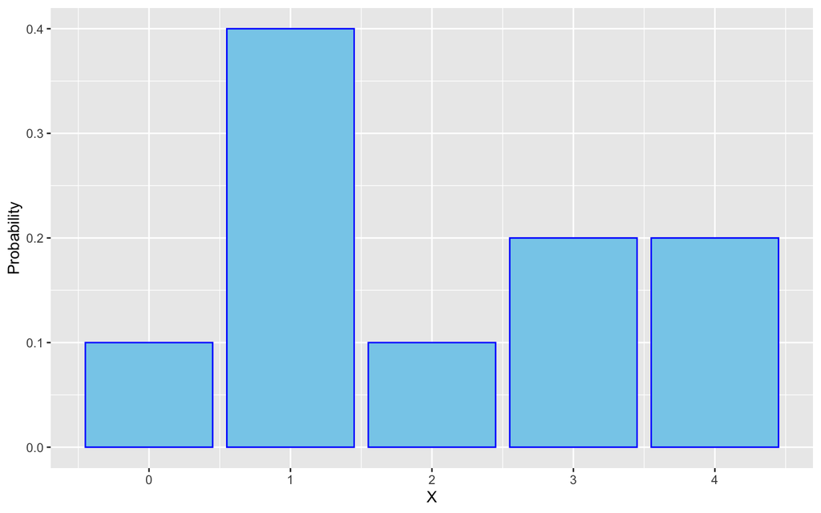

Each bar represents each of the value that the variable $X$ can take. The probability of each of those values is given by the height of the bars and the probability of more than one point, say $P(2\leq X\leq 4)$, can be found by adding the height of the bars, i.e, $P(2\leq X\leq 4) = 0.1+0.2+0.2=0.5$.

The expected value, standard deviation and variance of a pmf is given as,

$$E(X) = \sum x * P(X = x)$$

and

$$\sigma^2 = \sum (x-\mu)^2*P(X=x).$$

The standard deviation can just be found by taking the square root of variance.

Example:

- Consider the bar graph shown above, the expectation of $X$ is

$$E(X) = 0*0.1 + 1*0.4 + 2*0.1+3*0.2+4*0.2
= 2$$

$$Var(X) = (0 - 2)^2*(0.1) + (1 -
2)^2*(0.4) + (2-2)^2*(0.1)+(3 - 2)^2*(0.2)+(4 - 2)^2*(0.2) =
1.8$$

$$\sigma = \sqrt{1.8}=1.34$$

- Consider a single roll of a fair six-sided die (let’s call this $D$):

$$E(D) = 1*P(D = 1) + 2*P(D = 2) + 3*P(D = 3) + 4*P(D = 4) + 5*P(D = 5) +
6*P(D=6) \\
= 1*(1/6) + 2*(1/6) + 3*(1/6) + 4*(1/6) + 5*(1/6) + 6*(1/6) = 3.5$$

$$Var(D) = \sum (x-3.5)^2*P(D=x) = (1 - 3.5)^2*P(D = 1) + + ... +
(6-3.5)^2*P(D = x) \\
= (1 - 3.5)^2*(1/6) + ... + (6-3.5)^2*(1/6) \approx 2.92$$

and thus, $\sigma = \sqrt{2.92}.$

Some very commonly used discrete probability distributions are:

- Bernoulli Distribution: Probability distribution for a random variable that only takes two values. Example: Tossing a coin once.
- Binomial Distribution: Probability distribution for a random variable that is a repeated trial of a bernoulli variable. Example: Tossing a coin ten times.
- Geometric distribution: Probability distribution for a random variable that measures the number of failures before the first success. Example: Tossing a coin till I get a head.
- Poisson distribution: Probability distribution for a random variable that measures number of events occurring in a fixed interval of time if these events occur with a known constant average rate and independently of the time since the last event.
- Discrete Uniform Distribution: Probability distribution for a random variable that takes discrete values in the interval [a,b] and the probability of each of the n outcomes is 1/n.

### Continuous Probability Distribution

The probability distribution of a continuous random variable is given by the *Probability Density Function* (PDF). The PDF is a function over the sample space $\Omega$ of a continuous random variable X from which the probability that X is within a certain interval can be obtained. It is always given as a function of $x$ where, $x$ takes values in a range and is graphed as a curve and is denoted as $f(x)$.

For a continuous random variable, the probability of $X$ (using the pdf $f(x)$)

- being exactly equal to a point, say $a$, is 0.

$$P(X=a)=\int_a^af(x)dx=0$$

- being between two values $a$ and $b$ can be found

$$P(a \leq X \leq b ) =
\int_a^bf(x)dx$$

Thus, the expected value and variance of a pdf is given as,

$$\mu = \int x \cdot f(x)dx$$
and
$$\sigma^2 = \int (x-\mu)^2 \cdot f(x)dx.$$

The standard deviation can just be found by taking the square root of variance.

You won’t be asked to find the mean (expected value) or deviation of a continuous random variable.

Few very commonly used continuous probability distributions are:

- Continuous Uniform Distribution: Probability distribution for a random variable that takes continuous values in the interval [a,b] and is assigned a constant density for each possible value.
- Exponential Distribution: Continuous distribution that assigns the probability to the distance between events that occur continuously and independently at a constant average rate.
- Normal Distribution: Continuous probability distribution which appears very often in statistical and natural settings.

### EXERCISE: What type of distribution should this variable have? Answer it by mentioning whether it should have a discrete or continuous distribution.

- How long until the next bus arrives?
- No. of days until a new lightbulb burns out.
- The roll of a fair 6 sided die.
- Number of calls a call center receives in a minute, considering that on average they receive 3 calls per minute at all times of day.
- Total no of people in Madison (250,000) who catch COVID-19.
- Speed of all cyclists participating in the Olympic triathalon.

In this course we will only discuss the Binomial and Normal distribution in detail. In the next lecture notes we will learn about these two.

### R functions:

We won’t be calculating most of the probabilities by hand and find them using R. There are 4 main R functions that you can use for any distribution. They can be used to find

1. The *density* (for continuous distribution) or *probability at a point* (for discrete distribution), these are the functions that start with a d followed by the distributions name. The arguments it takes is $x$ (the point at which you want the density or the probability) and the parameters of the distribution. General format of these functions is `ddist(x, parameters)`.
2. The *probability to the left* (or right) of a point $q$ of a distribution, these are functions that start with a p followed by the distributions name. General format of these functions is `pdist(q, parameters)`.
3. The *point to the right (or left) of a certain probability* or the point $x$ such that the area under the curve to the left or right of the distribution is $p$. General format of these functions is `qdist(p, parameters)`.
4. *Generate* $n$ number of outcomes from a given distribution, these functions are the r functions. General format of these functions is `rdist(n, parameters)`.

We will see in detail about these functions for the Binomial and Normal distribution in the next lecture notes.